# Analyzing Chicago Traffic Accidents

### Exploring Damage

Now we also note that there's a damage column, lets look and see what values it could contain. We care about the ammount of damage done to cars, as it could offer insight into the serverity

```python
df['DAMAGE'].unique()
```

```
array(['OVER $1,500', '$500 OR LESS', '$501 - $1,500'], dtype=object)
```

Now we can note that we have catagorical variables. Now lets see how they relate to other variables. Mean is a measure of center that can be limited as it doesn't give the entirety of distribution, but could lead to new insights. Note that it's not a perfect measure for all columns, for example 24 and 00 for crash hour are very similar times, but would effect the mean differently.

```python
damage_totals =  df.groupby('DAMAGE').mean()
```

```python
damage_totals
```

| DAMAGE | POSTED_SPEED_LIMIT | LANE_CNT | STREET_NO | BEAT_OF_OCCURRENCE | NUM_UNITS | INJURIES_TOTAL | INJURIES_FATAL | INJURIES_INCAPACITATING | INJURIES_NON_INCAPACITATING | INJURIES_REPORTED_NOT_EVIDENT | INJURIES_NO_INDICATION | INJURIES_UNKNOWN | CRASH_HOUR | CRASH_DAY_OF_WEEK | CRASH_MONTH | LATITUDE | LONGITUDE |
| --- | --- | --- | --- | --- | --- | --- | --- | --- | --- | --- | --- | --- | --- | --- | --- | --- | --- |
| $500 OR LESS | 27.764148 | 10.703064 | 3401.498561 | 1246.439792 | 1.972720 | 0.181026 | 0.000737 | 0.021389 | 0.106661 | 0.052688 | 1.936978 | 0.0 | 13.450634 | 4.138276 | 6.639934 | 41.856278 | -87.661852 |
| $501 - $1,500 | 28.031858 | 30.111058 | 3656.291309 | 1296.824057 | 2.001591 | 0.074929 | 0.000240 | 0.006662 | 0.035950 | 0.032186 | 2.064936 | 0.0 | 13.494321 | 4.138967 | 6.583893 | 41.860816 | -87.674602 |
| OVER $1,500 | 28.552125 | 5.240158 | 3710.441346 | 1210.109728 | 2.061340 | 0.227090 | 0.001560 | 0.025206 | 0.127953 | 0.072874 | 2.015132 | 0.0 | 13.055548 | 4.118328 | 6.610356 | 41.852216 | -87.674424 |

In addition lets look at how many total of each catagory there are.

```python
x = list(df['DAMAGE'].unique()) # get unique catagorical values
x.sort()
```

```python
print(x)
```

```
['$500 OR LESS', '$501 - $1,500', 'OVER $1,500']
```

```python
# here we count the total number of rows that match each type
a = df[df.DAMAGE == '$500 OR LESS'].shape[0]
b = df[df.DAMAGE == '$501 - $1,500'].shape[0]
c = df[df.DAMAGE == 'OVER $1,500'].shape[0]
yTotal = [a,b,c]
```

```python
yTotal
```

```
[63930, 145804, 291048]
```

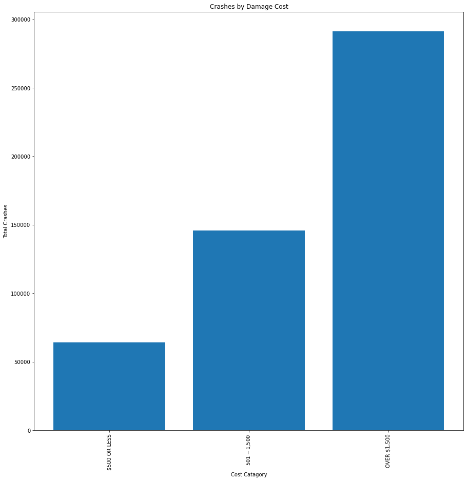

```python
# Make our plot
plt.figure(figsize=(15,15))
plt.bar(x, yTotal)
plt.title("Crashes by Damage Cost")
plt.xlabel("Cost Catagory")
plt.ylabel("Total Crashes")
plt.xticks(rotation="vertical")
plt.show()
```

Very interestingly when there are car crashes they are more likely to cause more damage. This could be a response bias thing as if there's minimal damage people might just walk away and not be bothered, as a 100 dollar scratchup may not be worth increases in insurance rates later on.

### Exploring Speed limits

Another natural question we ask is how fast are the drivers driving when they are crashed. Driving faster can be quite dangerous. Our dataset doesn't have the speed data, but what it does have is speed limit data, which can serve as a proxy.

```python
x = list(df['POSTED_SPEED_LIMIT'].unique())
x.sort()
```

```python
print(x)
```

```
[0, 1, 2, 3, 4, 5, 6, 7, 9, 10, 11, 12, 14, 15, 16, 18, 20, 22, 23, 24, 25, 26, 29, 30, 31, 32, 33, 34, 35, 36, 38, 39, 40, 45, 49, 50, 55, 60, 63, 65, 70, 99]
```

Interestingly therely a 99 posted speed limit

```python
yTotal = []
for i in x:
    a = df[df.POSTED_SPEED_LIMIT == i].shape[0]
    yTotal.append(a)
```

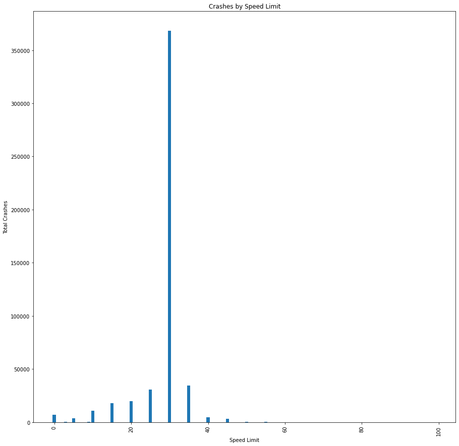

```python
# Make our plot
plt.figure(figsize=(15,15))
plt.bar(x, yTotal)
plt.title("Crashes by Speed Limit")
plt.xlabel("Speed Limit")
plt.ylabel("Total Crashes")
plt.xticks(rotation="vertical")
plt.show()
```

Wow, this is incredibly interesting. There's a significant ammount of crashes at 30, with it falling off significantly when it's smaller and larger than that value. This could potentially be for a number of reasons that could be interesting for futher study, such as there just being more places with speed limit of 30, or places with speed limit 30 are at areas that may be more damagerous.

Lets continue to look at more pieces of data and try too see if they could prove interesting. Lets look at the potential values of the crash types.

```python
df['CRASH_TYPE'].unique()
```

```
array(['NO INJURY / DRIVE AWAY', 'INJURY AND / OR TOW DUE TO CRASH'],
      dtype=object)
```

We can see that this doesn't present us with much to work with, as it's likely already captured in other portions of data such as injury

### Exploring Correlations through a HeatMap

Now lets take a detour and look at a heatmap, we want to see how our data is related to each other in another way. A heapmap allows us to quickly itentify pieces of information that can be quickly associated so we can do further investigations. Visually we can see both numbers and the darkness of the square to represent the strength of the relationship.

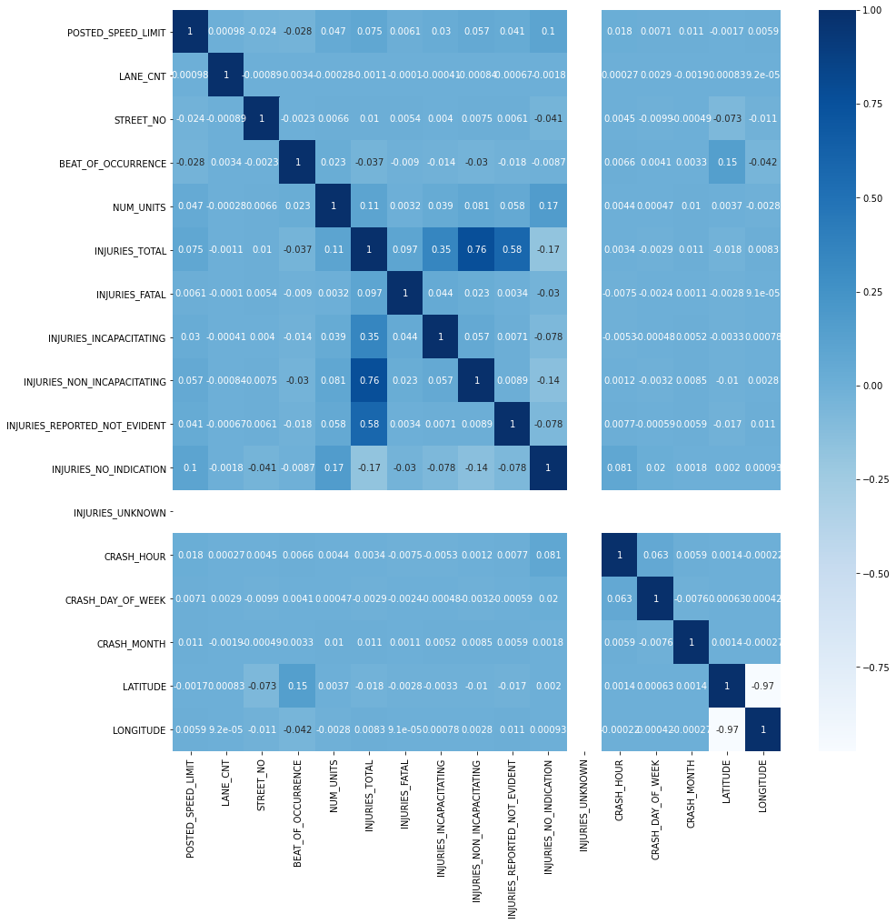

```python
plt.figure(figsize=(15,15))
sns.heatmap(df.corr(), annot=True, cmap='Blues')
plt.show()
```

### Exploring Time reported

We note that we have two dates, the time an incident occured and when it was reported. We would like to note that we doing this can give information about how fast incidents are reported, so going into the future we can maybe detect if the reported time is incredibly unlikely. Note that we are taking advantage of the fact that the data is well formated and that pandas is has a very good to_datetime function to conver the date times without having to have a format specifier. We visually check to see if the conversion worked as intended.

```python
df['CRASH_DATE_TIME_SERIES'] = pd.to_datetime(df['CRASH_DATE'].str.strip())
```

```python
df['CRASH_DATE_TIME_SERIES']
```

```
0        2019-07-10 17:56:00
1        2017-06-30 16:00:00
2        2020-07-10 10:25:00
3        2020-07-11 01:00:00
4        2020-07-08 14:00:00
                 ...
500777   2021-01-18 09:00:00
500778   2021-01-19 21:23:00
500779   2021-01-20 20:20:00
500780   2021-01-20 17:00:00
500781   2021-01-20 17:50:00
Name: CRASH_DATE_TIME_SERIES, Length: 500782, dtype: datetime64[ns]
```

```python
df['DATE_POLICE_NOTIFIED_TIME_SERIES'] = pd.to_datetime(df['DATE_POLICE_NOTIFIED'].str.strip())
```

```python
df['DATE_POLICE_NOTIFIED_TIME_SERIES']
```

```
0        2019-07-10 18:16:00
1        2017-06-30 16:01:00
2        2020-07-10 10:25:00
3        2020-07-11 08:30:00
4        2020-07-08 14:15:00
                 ...
500777   2021-01-19 20:29:00
500778   2021-01-19 21:24:00
500779   2021-01-20 20:22:00
500780   2021-01-20 18:00:00
500781   2021-01-20 18:07:00
Name: DATE_POLICE_NOTIFIED_TIME_SERIES, Length: 500782, dtype: datetime64[ns]
```

Next we would like to take the difference between the two date times, we want the format to be in seconds.

```python
df['TIME_TO_REPORT'] = (df['DATE_POLICE_NOTIFIED_TIME_SERIES']- df['CRASH_DATE_TIME_SERIES'])
```

```python
df['TIME_TO_REPORT']
```

```
0        0 days 00:20:00
1        0 days 00:01:00
2        0 days 00:00:00
3        0 days 07:30:00
4        0 days 00:15:00
               ...
500777   1 days 11:29:00
500778   0 days 00:01:00
500779   0 days 00:02:00
500780   0 days 01:00:00
500781   0 days 00:17:00
Name: TIME_TO_REPORT, Length: 500782, dtype: timedelta64[ns]
```

We would like to see the distribution of the time to report in a boxplot. We can see that there are a significant ammount of outliers, which is very interesting. The botplot detects these if the values are larger than 50% more than the interquartile range. We think that these do pose interesting pieces of information still, the reason is that many of the reports can be fairly quick, within a few minutes, so if some of the reports were a day after or the next day, they would be an order of mangitude after and wouldn't fit in a simple multiple of the IQR.

[figure not shown]

```python
fig, ax = plt.subplots()
ax.boxplot(df['TIME_TO_REPORT'])
plt.title("Distribution of Time to Report")
plt.ylabel("Time in Seconds")
plt.show()
```

We will explore this futher towards to end of the data analysis section to see if there's a relationship over time between time reported and the distribution of the time to report, as it could illustrate if reporting has gotten better over time.

## Data Analysis.

We choose to first do a linear regression for our data analysis, because it's a fairly simple techique that captures relations that is interpretable and understandable. There are associated pieces of information such as R^2 value where we can understand how much a variable contributes to another variable. There are more complicated models, but Given the limited range of the values of data, they might be overfitting.

We do the following mapping "['500 OR LESS', '501 - 1,500', 'OVER 1,500']" to [0,500,1500] respecitvely, for the lowerbounds of each of the intervals. The reason for this is we want a consistent mappng and 1500 has no upper bound on that interval.

```python
# mapping dictionary
di = {'$500 OR LESS': 0, '$501 - $1,500': 500, 'OVER $1,500': 1500}
```

```python
df2 = df.copy()
```

```python
# map the specific column
df2["DAMAGE_CONVERTED"] = df2["DAMAGE"].map(di)
```

```python
## see the comparison
df2['DAMAGE'].head(5)
```

```
0     OVER $1,500
1     OVER $1,500
2     OVER $1,500
3    $500 OR LESS
4     OVER $1,500
Name: DAMAGE, dtype: object
```

```python
df2['DAMAGE_CONVERTED'].head(5)
```

```
0    1500
1    1500
2    1500
3       0
4    1500
Name: DAMAGE_CONVERTED, dtype: int64
```

Now lets plot a scatter plot of our converted damage with a linear regression to see if a pattern exists, and how strong the pattern would be

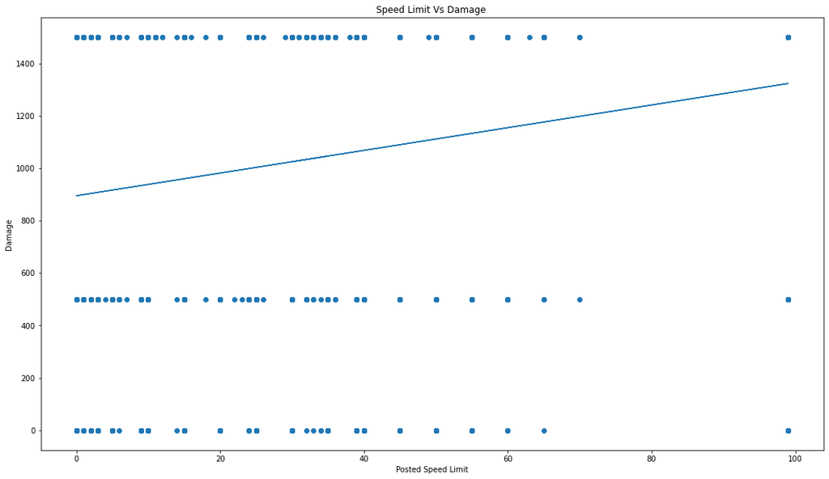

```python
curr_df = df2
fig, ax = plt.subplots()
fig.set_size_inches(18.5, 10.5, forward=True)
# linear regression plotted
xt = curr_df['POSTED_SPEED_LIMIT']
yt = curr_df['DAMAGE_CONVERTED']
m,b = np.polyfit(xt, yt, 1)
plt.plot(xt, b + m * xt, '-')
# plot the scatter
x = xt
y = yt
ax.scatter(x, y)
ax.set_title("Speed Limit Vs Damage ")
ax.set_xlabel('Posted Speed Limit')
ax.set_ylabel('Damage')
plt.show()
```

We can see that there's a slightly uptrend with our line, but looking at the data ploted itself, there doesn't appear to be a significant relationship.

```python
#reshape turns rows into columns
X = xt.values.reshape(-1, 1)
y = yt.values.reshape(-1, 1)
```

```python
lr = LinearRegression()
lr.fit(X,y)
```

```
LinearRegression()
```

```python
 lr.coef_ #coefficient
```

```
array([[4.3256522]])
```

```python
 lr.intercept_ #intercept
```

```
array([894.94065994])
```

```python
print("R^2 = {}".format(lr.score(X, y)))
```

```
R^2 = 0.0022628171546577036
```

To see how effective our model was we used the R^2 value. For reference (https://statisticsbyjim.com/regression/interpret-r-squared-regression/). The r^2ed value captures how much the dependant variable, for us the damage, the is explained by independant variable, the speed limit. In this case only .2% of the damage can be attributed to the speed limit.

One of the probably reasons for this is the courseness of the data. There isn't much diferentiating factors between the larger damage situations. a complete totaling would be the same as having to replace a door for example. With only three catagories perhase there wasn't as much that was able to be picked up from our simple model.

lets try something similar with speed limit but with injuries now, we have less courase data, and we can suspect see that there's a relationship between speed and injury likelyhood, due to kinetic energy increasing with the square of speed.

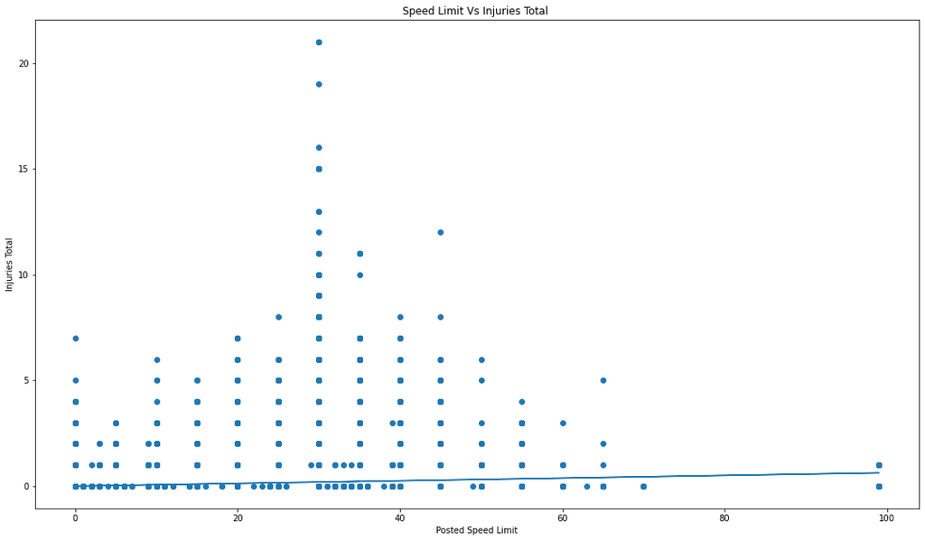

```python
curr_df = df2
fig, ax = plt.subplots()
fig.set_size_inches(18.5, 10.5, forward=True)
# linear regression plotted
xt = curr_df['POSTED_SPEED_LIMIT']
yt = curr_df['INJURIES_TOTAL']
m,b = np.polyfit(xt, yt, 1)
plt.plot(xt, b + m * xt, '-')
# plot the scatter
x = xt
y = yt
ax.scatter(x, y)
ax.set_title("Speed Limit Vs Injuries Total ")
ax.set_xlabel('Posted Speed Limit')
ax.set_ylabel('Injuries Total')
plt.show()
```

```python
#reshape turns rows into columns
X = xt.values.reshape(-1, 1)
y = yt.values.reshape(-1, 1)
lr = LinearRegression()
lr.fit(X,y)
```

```
LinearRegression()
```

```python
 lr.coef_ #coefficient
```

```
array([[0.00631612]])
```

```python
 lr.intercept_ #intercept
```

```
array([-0.00183921])
```

```python
print("R^2 = {}".format(lr.score(X, y)))
```

```
R^2 = 0.005558842279803189
```

We can see from the R^2 value that the speed limit explains very little, .5%, of the Total Injuries which is an interesting finding because one would think that how fast someone is going is directly related to the occurance and total of injuries. However what this could indicate is that the speed limit isn't indicative of the type or pace of the accidents that occur.

We haven't found as many significant relationships yet, so lets keep digging. From our heatmap, one of the relatively strong relationships was between the number of units involved and if there was any injuries involved, so lets explore that.

```python
df2['NUM_UNITS'].unique()
```

```
array([ 2,  3,  1,  4,  5,  8,  7,  6, 12, 14,  9, 11, 10, 15, 18, 16])
```

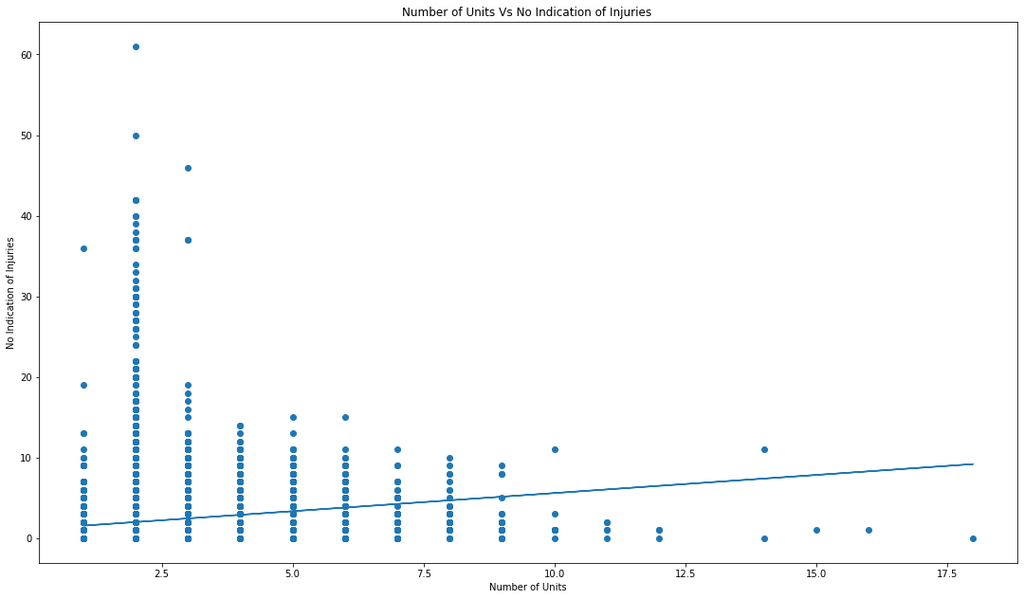

```python
fig, ax = plt.subplots()
fig.set_size_inches(18.5, 10.5, forward=True)
# linear regression plotted
xt = df2['NUM_UNITS']
yt = df2['INJURIES_NO_INDICATION']
m,b = np.polyfit(xt, yt, 1)
plt.plot(xt, b + m * xt, '-')
# plot the scatter
x = xt
y = yt
ax.scatter(x, y)
ax.set_title("Number of Units Vs No Indication of Injuries ")
ax.set_xlabel('Number of Units')
ax.set_ylabel('No Indication of Injuries')
plt.show()
```

```python
#reshape turns rows into columns
X = xt.values.reshape(-1, 1)
y = yt.values.reshape(-1, 1)
lr = LinearRegression()
lr.fit(X,y)
```

```
LinearRegression()
```

```python
 lr.coef_ #coefficient
```

```
array([[0.449225]])
```

```python
 lr.intercept_ #intercept
```

```
array([1.10654662])
```

```python
print("R^2 = {}".format(lr.score(X, y)))
```

```
R^2 = 0.028931655111896326
```

```python
df3 = df.copy()
```

```python
def timestamp_to_datetime(raw):
    return datetime.fromtimestamp(raw/1000)
```

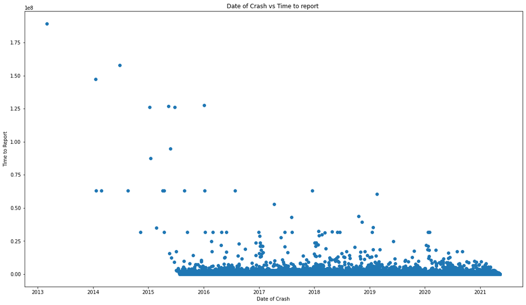

```python
fig, ax = plt.subplots()
fig.set_size_inches(18.5, 10.5, forward=True)
xt = df3['CRASH_DATE_TIME_SERIES']
yt = df3['TIME_TO_REPORT'].dt.total_seconds()
#plot the scatter
x = xt
y = yt
ax.scatter(x, y)
ax.set_title("Date of Crash vs Time to report ")
ax.set_xlabel('Date of Crash')
ax.set_ylabel('Time to Report')

plt.show()
```

```python
#reshape turns rows into columns
X = xt.values.reshape(-1, 1)
y = yt.values.reshape(-1, 1)
lr = LinearRegression()
lr.fit(X,y)
```

```
LinearRegression()
```

```python
 lr.coef_ #coefficient
```

```
array([[-4.74848908e-13]])
```

```python
 lr.intercept_ #intercept
```

```
array([787843.403639])
```

We can see that over time the time to report the data has gotten smaller and smaller. We run a linear model on the untransformed model and realize that overall reporting time has gotten faster over time. The tail end reporting times have gotten better over time. However the low value of our regression slope being close to 0 would indicate that while it is improving for the tail end, there isn't a significant ammount of improvement for most of the report times.

## Conclusion

In conclusion we can see that there some limited relationships between different factors, of which we have explored a few. There are some limitations to the nature of the dataset. One of them is that it only gives times that we crashed. If we wanted to measure how safe something is we would have to do a metric such as crashes per times that a particular section of road is used, or ratio of crash incidents to non crash incidents per car in unit of time. This would require a system of survence cameras to capture this information.

Despite these limitations we have found some interesting pieces of information. For example the distribution of speed limits was centered arround 30. In addition there's fairly weak correlations between many of these variables, which can indicate that there are many factors to crashes. We've explored a few variables to try to see relationships. One of the stronger ones was the number of vehicles and then the lack of injuries. Thankfully from our data in general in many car accidents there are very few injuries at all, which is great news for public safety. In addition we can see that the worst times it took to report an accident have gotten better over time, most of the times have remained fairly consistent.

In addition, there are many parts of the data we could explore in the future. We could explore how time of day impacts collisions. We could explore geolocation and group clusterings of the occurances of the crashes. There are simply many aspects of the data that one could explore further

What we can observe through this is the ability for us to tell a story and communicate ideas through Python. With the tools of visualizations, machine learning, and statistical tests we are better able to dive deep and examine relationships of the world arround us.

## Resources For Futher Reading/learning.

Now that you've come to the end you might want to learn more. To Learn more about machine learning I would recommend Elements of Statistical Learning. https://web.stanford.edu/~hastie/Papers/ESLII.pdf

In addition, anther resource for machine learning would be A classic from Bishop ,PRML, https://www.amazon.com/Pattern-Recognition-Learning-Information-Statistics/dp/0387310738 .

To learn more about Pandas I would recommend a classic from the inventor of Pandas. https://www.amazon.com/Python-Data-Analysis-Wrangling-IPython-ebook/dp/B075X4LT6K.

Other Sources related to statistics, machine learning, and domain specific topics would include:

https://stats.idre.ucla.edu/spss/faq/coding-systems-for-categorical-variables-in-regression-analysis-2/

https://www.researchgate.net/profile/Priya-Prasad-8/publication/329110990_Development_of_Numerical_Models_for_Injury_Biomechanics_Research_A_Review_of_50_Years_of_Publications_in_the_Stapp_Car_Crash_Conference/links/5c103151a6fdcc494fed905e/Development-of-Numerical-Models-for-Injury-Biomechanics-Research-A-Review-of-50-Years-of-Publications-in-the-Stapp-Car-Crash-Conference.pdf

https://www.sciencedirect.com/science/article/pii/S1369847800000140?casa_token=CpVwUQ5160QAAAAA:quizAAw-AHedqy1qxKgzGEB3Ykq86xrYGl6PunWOFsJQtaNirGuqrAT6ZGy69n2WYWGV3roUdZE